# Tuskegee Airmen

Trent Brunson

Dec 6, 2023

Read in the dataset:

```r
tuskegee <- readr::read_csv('https://raw.githubusercontent.com/rfordatascience/tidytuesday/master/data/2022/2022-02-08/airmen.csv')
head(tuskegee)
```

```
## # A tibble: 6 × 16
##   name         last_name first_name graduation_date     rank_at_graduation class
##   <chr>        <chr>     <chr>      <dttm>              <chr>              <chr>
## 1 Adams, John… Adams     John H., … 1945-04-15 00:00:00 2nd Lt             SE-4…
## 2 Adams, Paul  Adams     Paul       1943-04-29 00:00:00 2nd Lt             SE-4…
## 3 Adkins, Rut… Adkins    Rutherfor… 1944-10-16 00:00:00 2nd Lt             SE-4…
## 4 Adkins, Win… Adkins    Winston A. 1944-02-08 00:00:00 2nd Lt             TE-4…
## 5 Alexander, … Alexander Halbert L. 1944-11-20 00:00:00 2nd Lt             SE-4…
## 6 Alexander, … Alexander Harvey R.  1944-04-15 00:00:00 2nd Lt             TE-4…
## # ℹ 10 more variables: graduated_from <chr>, pilot_type <chr>,
## #   military_hometown_of_record <chr>, state <chr>,
## #   aerial_victory_credits <chr>, number_of_aerial_victory_credits <dbl>,
## #   reported_lost <chr>, reported_lost_date <dttm>,
## #   reported_lost_location <chr>, web_profile <chr>
```

More information about the dataset can be found at this [Tidy Tuesday repo](https://github.com/rfordatascience/tidytuesday/blob/master/data/2022/2022-02-08/readme.md).

Further context and references about the famed Tuskegee Airmen can be found at these credible websites:

- [tuskegeeairmen.org](https://www.tuskegeeairmen.org/wp-content/uploads/2020/11/TAI_Resources_Tuskegee-Airmen-Questions-and-Answers-09_2014.pdf): an USAF organization dedicated to preserving the history of the USAF
- [USAF Tuskegee Airmen Heritage](https://www.usafa.edu/wwii-airpower-legend-receives-honorary-promotion-to-colonel/): a recent event this month in the USAF with a Tuskegee pilot
- [The Tuskegee Airmen Honor Court](https://www.usafa.af.mil/News/Article/619405/usafa-honors-tuskegee-airmen/): an illustration of the USAF heritage at USAFA

**Question:** Who are the Tuskegee Airmen? Where did Tuskegee Airmen come from?

**Introduction:** The Tuskegee Airmen are a famed group of black, WWII male pilots named after the city near their training field in Tuskegee, Alabama. Their legacy lives on today in the United States Air Force (USAF) and at my alma mater, the United States Air Force Academy (USAFA). In fact, the Tuskegee Airmen legacy is memorialized in a special place at the United States Air Force Academy, in its Honor Court.

With that context, the dataset above will be used to illustrate where these Airmen came from in the United States of America. The dataset is little more than a list of training and dates at the Tuskegee airfield in Alabama, where the group derives their name. The data includes name in three columns, training class name, graduation date, training location, hometown and state. It also includes training and combat information such as pilot type (which has 4 valid values), aerial combat data and links to web profiles of some of the Airmen (only about 20%). The four pilot types included 1) single engine, 2) twin engine, 3) service and 4) liaison. Single went to fighter tracks, twin to bomber tracks, liaison did observation and aerial spotting for ground forces, with service flying transports and other aircraft like trainers. The data has no content about missions other than fighter roles (ground attack, observer missions, service, etc.).

**Approach:** Since, there is very limited information about combat roles and combat support roles in this dataset, the report will first examine the composition of training types. It will derive some values of the pilot types that graduated to become members of the Tuskegee Airmen (whether trained there or not - all black WWII pilots of this era are commonly referred to as Tuskegee Airmen since that is from where the preponderance of US black pilots graduated).

To examine from where the Tuskegee Airmen hail, this report will use the provided dataset and pull the geometries using the rnaturalearth package, then converting the data type to use in sf and plot with state boundaries generated from rnaturalearth.

**Analysis:**

### Exploratory Data Analysis

Output suppressed for report clarity. See comments for details of findings and table and development details.

```r
# EDA & data cleansing
nrow(tuskegee)  # 1006 rows
str(tuskegee)  # aerial victories in number, all other are chr data types
unique(tuskegee)  # all unique entries
colSums(!is.na(tuskegee))
# name                  last_name                 first_name
# 1006                     1006                      1006
# graduation_date       rank_at_graduation        class
# 995                      1001                      986
# graduated_from         pilot_type               military_hometown_of_record
# 1006                     1006                      997
# state                 aerial_victory_credits    number_of_aerial_victory_credits
# 995                      72                        1006
# reported_lost         reported_lost_date        reported_lost_location
# 2                        2                         2
# web_profile
# 193

# counts of unique values in each df column
sapply(tuskegee, data.table::uniqueN)
# returned:
 #            name                        last_name                       first_name
 #            1003                              617                              804
 # graduation_date               rank_at_graduation                            class
 #              53                                8                               73
 #  graduated_from                       pilot_type      military_hometown_of_record
 #               4                                5                              367
 #           state           aerial_victory_credits number_of_aerial_victory_credits
 #              49                               51                                6
 #   reported_lost               reported_lost_date           reported_lost_location
 #               2                                2                                2
 #     web_profile
 #             191

# get counts of each value
# sapply(tuskegee, function(x) table(x))
lapply(tuskegee, function(x) length(table(x)))  # list easier to read

summary(tuskegee)

unique(tuskegee$pilot_type)
# 4 pilot types: "Single engine" "Twin engine"   "Liaison pilot" "Service pilot" "Liason pilot"
  # liaison misspelled - group these together
```

### Table computations

```r
# Graduating pilots,Bomber escort missions, Bomber missions, POW
# year  liaison pilots  single (fighter) twin(bomber and CAS)
# totals of each

# dates <- as.Date(tuskegee$graduation_date, "%d-%b-%y")
# years <- format(dates, "%Y")
# tapply(tuskegee$year, years)
# need lubridate package for above - not permitted in course
# move on to summarizing pilot roles

# correct the misspelling
tuskegee$pilot_type[tuskegee$pilot_type == "Liason pilot"] <- "Liaison pilot"
tuskegee_table <- tuskegee |> group_by(pilot_type) |>
  summarize(number_pilots = n()) |>
  mutate(percent_of_pilots = scales::label_percent()(number_pilots/sum(number_pilots))) %>%
  # add a row to show the total number of pilots
  # %>% nust be used instead of |>
  bind_rows(summarize(., across(where(is.numeric), sum), across(where(is.character), ~'Total')))

tuskegee_table
```

```
# A tibble: 5 × 3
  pilot_type    number_pilots percent_of_pilots
  <chr>                 <int> <chr>
1 Liaison pilot            51 5.1%
2 Service pilot            11 1.1%
3 Single engine           697 69.3%
4 Twin engine             247 24.6%
5 Total                  1006 Total
```

#### **Table 1.** Pilot type breakdown

### Geospatial plotting

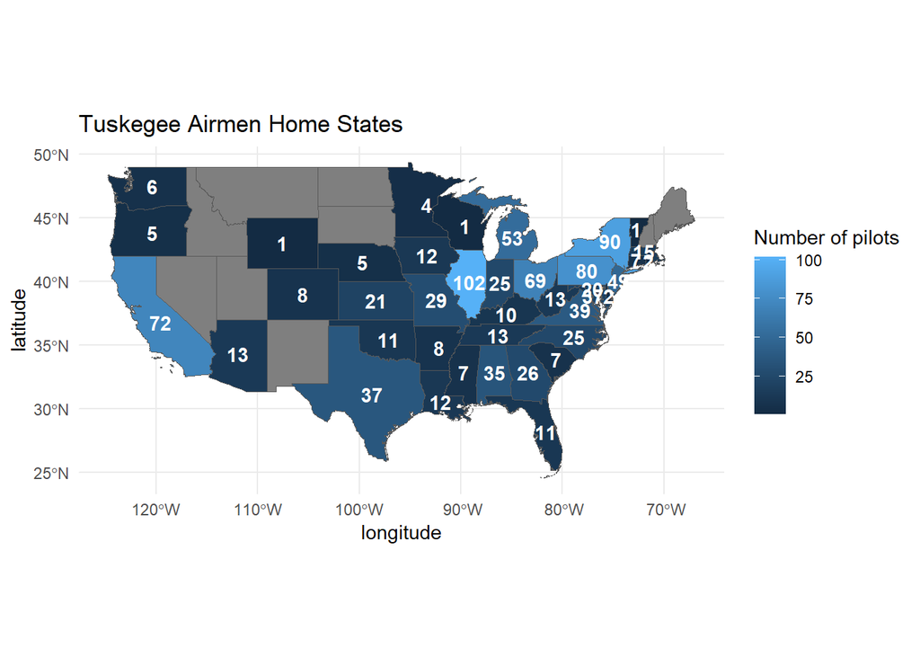

```r
# show states with links to profiles
# states <- ne_countries(scale = "medium", country = "united states of america", returnclass = "sf")
us_states <- ne_states(country = "united states of america", returnclass = "sf") |>
  filter(! name %in% c('Alaska', 'Hawaii'))

us_states <- us_states |> rename("state" = "postal")
# colnames(us_states)

tusk_states <- tuskegee |>
  group_by(state) |>
  summarize(number_from = n())
    # drop HT, Haiti
# tusk_states
# newdf <- tusk_states |> left_join(select(us_states, state, geometry), by = "state")

# reverse this - geom_sf couldn't find the geometry column even when explicitly expressed
reverse <- us_states |> left_join(select(tusk_states, state, number_from), by = "state")

ggplot(reverse) +
  geom_sf(aes(fill = number_from)) +
  labs(fill = "Number of pilots") +
  geom_text(data = reverse, aes(x = longitude, y = latitude, label = number_from),
  color = "white", fontface = "bold", check_overlap = FALSE) +
  theme_minimal() +
  ggtitle("Tuskegee Airmen Home States")
```

### **Figure 1.** Tuskegee Airmen breakdown by home state

**Discussion:** This was a challenging dataset to work with as it was almost entirely qualitative and observational - not much room for statistical analysis as typically done. But sticking with it because of interest in the important topic of the Tuskegee Airmen allowed development of other aspects of data visualization. In the end, data analysis and visualization is about persuasion. Persuading the data analyst, their boss, the executive, the customer or client. Data visualization is about telling the story along three fronts: ethos, pathos and logos. Ethos, the Latin root for ethics in English is doing the right thing argument. Recognizing great citizens and their contribution (whichever country you’re from) is the right thing to do. Telling the story that persuades and nudges through relatable attributes is the root of pathos (feeling). Providing context and background about these selfless individuals creates a relatable affinity. And the last is typically a data analysts or scientists staple, logos, or logical arguments. It is important but perhaps not as important the first and when coupled with pathos, can be very powerful. But alone, logos does little to transform. That is why I chose to work on an effort to relay an emotionally significant period in United States military history.

The Tuskegee Airmen legacy continues strong and with prominence in the USAF (see [The Tuskegee Airmen](https://www.usafa.edu/wwii-airpower-legend-receives-honorary-promotion-to-colonel/)). These were stalwart men who chose to serve a nation and overcome extraordinary social obstacles. The table shows and unusually large proportion of Tuskegee Airmen were directed to single seat aircraft after training. Typically it is well less than half that enter fighter pilot tracks, whereas they nearly doubled that rate at 70%. This may be due in part from tactics to minimize interactions between whites and blacks in close quarters of a shared cockpit in a bomber or a service aircraft like a transport. The existing pilot population most likely reflected the social makeup of the country and its attitudes at the time. There were separate eating establishments, classrooms and schools, down to the toilet facilities. The Army Air Corps leadership may have felt this was a way to limit the amount of barriers and resistance faced in allowing blacks to fly US aircraft.

The graphic shows the distribution from where the Tuskegee Airmen originated. There is a marked concentration in the northeast. This may reflect attitudes from 75 years earlier, following the end of the US civil war, where blacks experienced more shared freedoms than the southern states provided. And perhaps that reflected in the attitude of volunteers to join and serve the US military during WWII. It would be of further interest to join another dataset to this showing 1940’s population and extract rates of service among black Americans to see if that supports or debunks the previous observation.